# Part I - (Dataset Exploration Title)

Next I'll check out the CreditScoreRangeUpper to see how it relates to the BorrowerRates

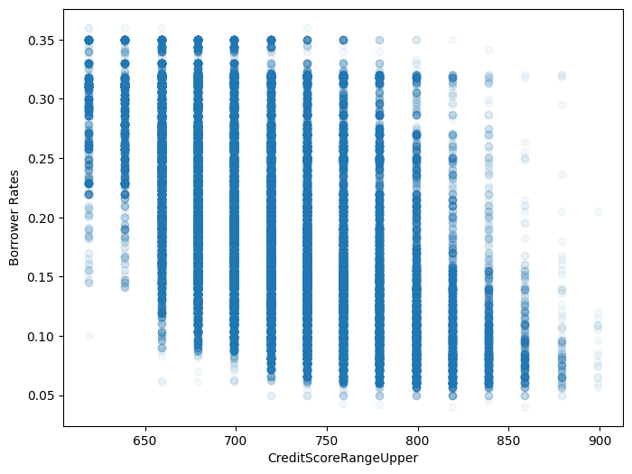

```python
plt.figure(figsize=[8, 6])
plt.scatter(x=data.CreditScoreRangeUpper, y=data.BorrowerRate, alpha=0.05)
plt.ylabel('Borrower Rates')
plt.xlabel('CreditScoreRangeUpper');
```

From the plot above, it is evident that there is a negative relationship between the CreditScoreRangeUpper and this suggests that the higher values of the Borrower rates are most favored by lower CreditScoreRangeUpper values, while the lower values of Borrower rates are most favored by high CreditScoreRangeUpper values

Now, I'll be checking out the LoanOriginalAmount against the BorrowerRates to see if they hold any interesting properties.

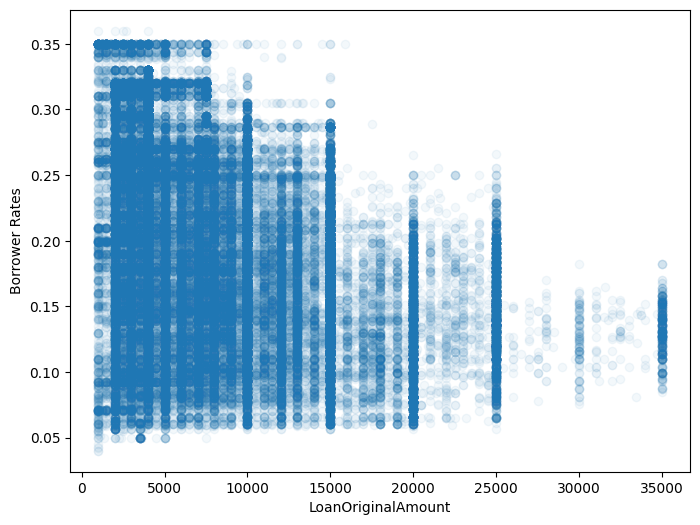

```python
plt.figure(figsize=[8, 6])
plt.scatter(data.LoanOriginalAmount, data.BorrowerRate, alpha=0.05)
plt.ylabel('Borrower Rates')
plt.xlabel('LoanOriginalAmount');
```

A negative relationship is observed between the BorrowerRate and the LoanOriginalAmount. This means that Loans whose original amount fall on the low side tend to end up with the highest borrower rates, whose those loans that their original amount fall on the low side have relatively low borrower rates. Another fact from the scatter plot above worth noting is that most of the entries fall on the low side of the LoanOriginalAmount and it is worth further analysis to see how the above distribution ends up when separated into categories of the other categorical variables. This will be further analyzed in the multivariate exploration section.

Also, I would like to see how the BorrowerRates are distributed across each ProsperRating category.

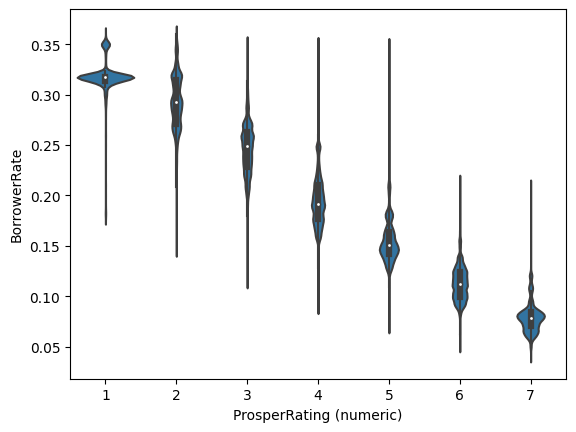

```python
sb.violinplot(data=data, x='ProsperRating (numeric)', y='BorrowerRate', color=defaultColor)
```

The above plot confirms the earlier observation made about the ProsperRatings being negatively correlated to the BorrowerRates. Another very important fact from the above plot is that for most categories of the ProsperRating, the BorrowerRates is distributed almost evenly across them, with the exceptions of the ProsperRating 1, 2 and 7. In both ProsperRating 1 and 7 the BorrowerRate appears roughly unimodal but for ProsperRating 2, the distribution of the BorrowerRate is somewhat trimodal with peak regions occurinng around the 25th percentile, median and the 75th percentile.

Next, I'll check out the relationships between several categorical variables and some numerical variables side-by-side to if I could gain more insight on the data through this

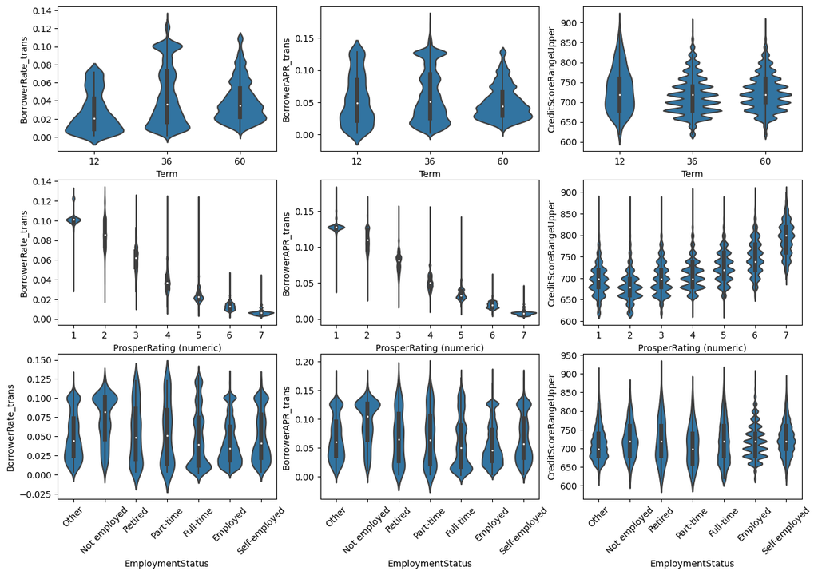

```python
catVars = ['Term','ProsperRating (numeric)', 'EmploymentStatus']
fig, ax = plt.subplots(ncols = 3, nrows = 3 , figsize = [15,10])

for i in range(len(catVars)):
    var = catVars[i]

    sb.violinplot(data = data, x = var, y = 'BorrowerRate_trans', ax = ax[i,0],
               color = defaultColor)

    sb.violinplot(data = data, x = var, y = 'BorrowerAPR_trans', ax = ax[i,1],
               color = defaultColor)

    sb.violinplot(data = data, x = var, y = 'CreditScoreRangeUpper', ax = ax[i,2],
               color = defaultColor)

ax[2,0].set_xticklabels(['Other' , 'Not employed' , 'Retired' , 'Part-time' , 'Full-time' , 'Employed' , 'Self-employed'], rotation=45)
ax[2,2].set_xticklabels(['Other' , 'Not employed' , 'Retired' , 'Part-time' , 'Full-time' , 'Employed' , 'Self-employed'], rotation=45)
ax[2,1].set_xticklabels(['Other' , 'Not employed' , 'Retired' , 'Part-time' , 'Full-time' , 'Employed' , 'Self-employed'], rotation=45);
```

The plot of the full data using a violin plot and variable transformations reveals much more than the earlier box plots. The plots of the BorrowerRate and the BorrowerAPR appear to have very similar distributions.It is worthy of note to mention that the average BorrowerRates and even average BorrowerAPR appear to drop with increasing ProsperRatings, this confirms the suggestion made initially of a negative relationship between the BorrowerRate and the ProsperRating when the boxplot was used to make the visualization.

### Talk about some of the relationships you observed in this part of the investigation. How did the feature(s) of interest vary with other features in the dataset?

Several of the other variables showed a great deal of correlation to the Borrower Rate even without performing any transfromation on the Borrower rates. The most notable of these variables is the ProsperRating(numeric) which had a negative relationship with the Borrower Rates, that is the lowest Borrower Rates end up with the highest ProsperRating. Another interesting relationship worthy of note is that the EstimatedLoss had a positive relationship with the Borrower Rates andon the transformation of the Borrower Rates a somewhat linear relationship was observed between these two variables. This suggests that the EstimatedLoss is highly dependent on the Borrower Rates.

## Multivariate Exploration

In this part of the analysis I would be majorly checking out how the categorical variables affect the Borrower Rates together with other quantitative variables.

I'll start by checking out the relationship between the ProsperRating, Borrower Rates and the LoanOriginalAmounts

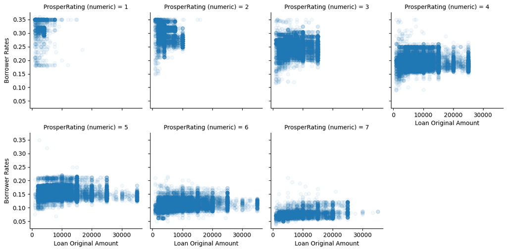

```python
# create faceted scatter plots on levels of the ProsperRating
g = sb.FacetGrid(data = data, col = 'ProsperRating (numeric)', col_wrap = 4, size = 3)
g.map(plt.scatter, 'LoanOriginalAmount', 'BorrowerRate', alpha=0.05)
g.set_xlabels('Loan Original Amount')
g.set_ylabels('Borrower Rates');
```

Lower ProsperRating scores are seen to fall on the low end of the Loan original amount but the borrower rates at these low scores are seen to be very high. On the other hand in the higher ProsperRating scores, a greater spread of values is seen across the loan original amount and the borrower rates at these high scores are seen to be the lowest in the distribution.

Following this, I'll be checking out the relationships between the BorrowerRate, the Investors and the ProsperRating with the aid of a heatmap so as to see regions that are more dense better.

```python
# function to create heatmap
def hist2dgrid(x, y, **kwargs):
    palette = kwargs.pop('color')
    plt.hist2d(x, y, bins = 16, cmap = palette, cmin = 0.5)
```

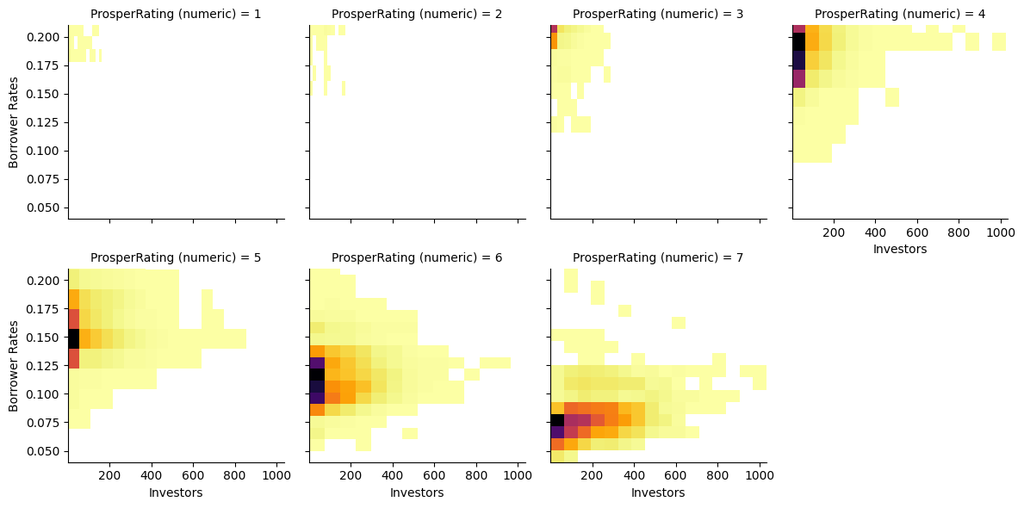

```python
# create faceted heat maps on levels of the ProsperRating
g = sb.FacetGrid(data = data, col = 'ProsperRating (numeric)', col_wrap = 4, size = 3)
g.map(hist2dgrid, 'Investors', 'BorrowerRate', color ='inferno_r')
g.set_xlabels('Investors')
g.set_ylabels('Borrower Rates');
```

From the faceted heatmaps above, an interesting relationship is observed between the BorrowerRates, Investors and ProsperRating. Across the ProsperRating, as the rating scores increase, the values for the investors go up. But this is in contrast with that for the BorrowerRates as the values for this variable decrease with increasing ProsperRating. Also the concentration of the data points is seen to slowly move from the top left corner to the lower left corner, this suggests that higher ProsperRatings and lower Investor value favour lower borrower rates

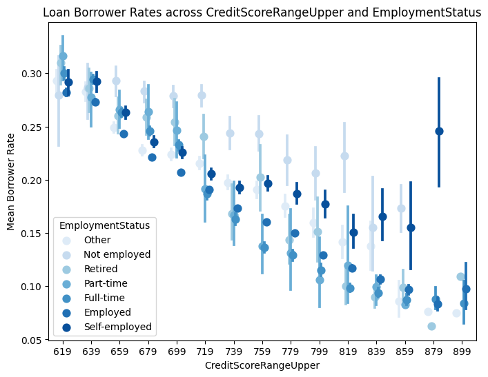

```python
# create a dummy dataframe to store a section of the data dataframe and then change the data type of
# CreditScoreRangeUpper to an int datatype to improve the visibility of the pointplot to be later created

tmp = data[['CreditScoreRangeUpper', 'BorrowerRate', 'EmploymentStatus']]
tmp.CreditScoreRangeUpper = tmp.CreditScoreRangeUpper.apply(int)

fig = plt.figure(figsize = [8,6])
ax = sb.pointplot(data = tmp, x = 'CreditScoreRangeUpper', y = 'BorrowerRate', hue = 'EmploymentStatus',
           palette = 'Blues', linestyles = '', dodge = 0.4)
plt.title('Loan Borrower Rates across CreditScoreRangeUpper and EmploymentStatus')
plt.ylabel('Mean Borrower Rate');
```

## Conclusions

The analysis focused on some of the features originally present in the dataset and the feature of interest was the BorrowerRate. The main insights gained from the analysis are as follows:

- There is a strong relationship between the BorrowerRate and the ProsperRating, the BorrowerRate is dependent on the ProsperRating and an approximately negative linear relationship may be seen between these variables
- The BorrowerRate is dependent on the LoanOriginalAmount and a negative relationship may be observed between them, although it is not as strong as that between the ProsperRating and the BorrowerRate
- The BorrowerRate and BorrowerAPR are collinear as the have very similar distribution and are highly positively correlated with each other
- The CreditScoreRangeUpper is negatively related with the average BorrowerRate in a CreditScoreRangeUpper value, and the not employed employment status usually have the highest average BorrowerRate.
- The EstimatedLoss, EstimatedEffectiveYield and EstimatedReturn are all dependent on the BorrowerRate and they are all positively correlated with the BorrowerRate, although they exhibit non-linear relationships with the BorrowerRate.